# 経営情報論 2024年度期末試験

藤野秀則,

2025-02-04

以下の各問の中のRのソースコードに記載する内容を，語群から選択して，記号を記入してください． なお，選択肢は複数回利用することがあります．

# 問1

Aさんの研究グループはゼミ研究の中で次のような仮説を立てました．

- 仮説1 企業の従業員数が多い企業ほど，世界的に名が通るような大企業が多くなるので，その会社の平均給与も高いのではないか．
- 仮説2 企業の平均勤続年数が長い企業ほど，それだけ収益が安定しているということなので，その会社の平均給与も高いのではないか．

そこで，就職四季報の最新版に記載されている1291社分の数値をグループメンバーで手分けしてCSVファイル(Shikihou.csv)を作成しました．CSVファイルは次のようなファイルとなっています．勤続年数は年を単位として小数第1位まで，平均給与は1万円を単位として千円台まで記載することにしました．

| 企業ID | 企業名 | 従業員数 | 勤続年数 | 平均給与 |
| --- | --- | --- | --- | --- |
| 1 | Company1 | 825 | 23.0 | 54.4 |
| 2 | Company2 | 783 | 9.5 | 48.0 |
| $\vdots$ | $\vdots$ | $\vdots$ | $\vdots$ | $\vdots$ |

このファイルを用いて仮説1と仮説2の検証を行うことにしました．

Aさんたちはまず，CSVファイルを読み込み，データの概要を確認することにしました．

```r
# データの読み込み
data <- read.csv("1_Shikihou.csv", header = TRUE, fileEncoding = "UTF-8")

# データの概要
summary(data)
```

```
##      企業ID          企業名             従業員数        勤続年数
##  Min.   :   1.0   Length:1291        Min.   :  108   Min.   : 9.30
##  1st Qu.: 323.5   Class :character   1st Qu.:  947   1st Qu.:12.20
##  Median : 646.0   Mode  :character   Median : 1813   Median :14.50
##  Mean   : 646.0                      Mean   : 3025   Mean   :14.66
##  3rd Qu.: 968.5                      3rd Qu.: 3460   3rd Qu.:16.80
##  Max.   :1291.0                      Max.   :46008   Max.   :24.40
##     平均給与
##  Min.   :32.60
##  1st Qu.:40.10
##  Median :42.00
##  Mean   :42.03
##  3rd Qu.:44.00
##  Max.   :52.30
```

Aさんたちはまず，仮説1の検証を行うことにしました．Aさん達は最初（ ）分析を行って，（ ）係数の値そのと有意性を確認することにしました．

```r
# 仮説1の検証
cor.test(data$従業員数, data$平均給与)
```

[output not shown]

仮説1の検証の結果，従業員数と平均給与の（ ）係数は0.17であり，また，有意であることがわかりました．

同様に仮説2についても検証しました．

```r
# 仮説2の検証
cor.test(data$勤続年数, data$平均給与)
```

[output not shown]

結果，勤続年数と平均給与の（ ）係数は0.12であり，また，有意であることがわかりました．

このことから，仮説1と仮説2は支持されることがわかりました．

このことを先生に報告すると，次のようなアドバイスを受けました．

> この係数の有意性はサンプル数が多くなると低い値でも有意になることがあるから，あまりこの値の有意性は重要視しなくても良いよ．

> それよりも， 仮説1については，名が通っていることが原因となって，従業員数が多くなったり，平均給与が高くなっている，という因果関係を想定しているよね．また，仮説2についても，収益が安定していることが原因となって，勤続年数が長くなったり，平均給与が高くなったりしているということだよね．このような因果関係も調べてみてはどうかな？

先生からのアドバイスを受けて，Aさんたちは，まずは「名が通っているかどうか」と「収益が安定しているかどうか」をどのようにすればデータとして表すことができるかを考えることにしました．

Aさんたちは，「名が通っているかどうか」について，名が通っている企業は東証一部に上場しているだろうと考え，東証一部に上場している企業に「上場」，それ以外の企業に「非上場」を割り当てたデータを作成することにしました．

また，「収益が安定しているかどうか」については，収益が安定している企業は，過去5年間の売上高の変動係数（標準偏差を平均で割ったもの）が低い企業だろうし，収益が不安定な企業は，過去5年間の売上高の変動係数が高い企業だろうと考え，過去5年間の売上高の変動係数を求めることにしました．

1291社すべてを調べるのは大変なので，12社ごとに等間隔にサンプリングを行い，その107社について，過去5年分の四季報などから「現在，東証一部上場しているかどうか」と「過去5年間の売上高の変動係数」を調べて，次のようなCSVファイル(Shikihou2.csv)を作成しました．

| 企業ID | 企業名 | 従業員数 | 勤続年数 | 平均給与 | 東証 | 変動係数 |
| --- | --- | --- | --- | --- | --- | --- |
| 1 | Company1 | 825 | 23 | 54.4 | 非上場 | 0.12 |
| 2 | Company13 | 1723 | 18 | 43.5 | 上場 | 0.25 |
| $\vdots$ | $\vdots$ | $\vdots$ | $\vdots$ | $\vdots$ | $\vdots$ | $\vdots$ |

このデータを用いて，改めて以下のような仮説を検証することとしました．

- 仮説1-1 東証1部上場企業は上場していない企業にくらべて，平均給与が高いのではないか．
- 仮説1-2 東証1部上場企業は上場していない企業にくらべて，従業員数が多いのではないか．
- 仮説2-1 変動係数が低い企業は変動係数が高い企業にくらべて，平均給与が高いのではないか．
- 仮説2-2 変動係数が低い企業は変動係数が高い企業にくらべて，平均勤続年数が長いのではないか．

Aさんたちは，まず，データの読み込みと概要を確認することにしました．

```r
# データの読み込み
data <- read.csv("Shikihou2.csv", header = TRUE, fileEncoding = "UTF-8")

# データの概要
summary(data)
```

次いで，上場・非上場で平均給与が違っているかを調べました．

```r
# 東証の給与への響
res.11 <- aov(平均給与 ~ 東証, data = data)
summary(res.11)
```

[output not shown]

続いて，上場・非上場で従業員数が違っているかを調べました．

```r
# 東証の従業員数への影響
res.12 <- aov(従業員数 ~ 東証, data = data)
summary(res.12)
```

[output not shown]

次に，変動係数が平均給与とどのような関係があるかを調べました．

```r
# 変動係数の給与への影響
res.21 <- lm(平均給与 ~ 変動係数, data = data)
summary(res.21)
```

[output not shown]

続いて，変動係数が勤続年数とどのような関係があるかを調べました．

```r
# 変動係数の勤続年数への影響
res.22 <- lm(勤続年数 ~ 変動係数, data = data)
summary(res.22)
```

[output not shown]

# 問2

このデータ(Yoka.csv)は講義でも取り上げた，過去の藤野ゼミのゼミ生が行った余暇の過ごし方に関する県大生へのアンケートで得られたデータです．

Bさんはこのデータを使って，県大生はどのような余暇の過ごし方をしているのかを調べてみたいと思いました． 分析を始めるにあたり，Bさんは，今のままでは変数名が長くなってしまうので，以下の表の通りにExcel上で変数名を変更しました．

| 変数名 | 元の変数名 |
| --- | --- |
| Q1 | 性別 |
| Q2 | 学年 |
| Q3 | 現在の住居形態 |
| Q4 | 自身の金銭感覚..どちらか近いと思う方に答えてください. |
| Q5 | 外向性 |
| Q6 | 親和性 |
| Q7 | 勤勉性 |
| Q8 | 神経症傾向 |
| Q9 | 開放性 |
| Q10 | 必要以外の睡眠をする.昼寝など. |
| Q11 | 家でYouTubeやNetflixなど動画を見て過ごす |
| Q12 | パチンコや競艇などギャンブルに出かける |
| Q13 | ショッピングに行く |
| Q14 | 部活.サークルや地域クラブなどで運動する |
| Q15 | ボランティア活動に参加する |
| Q16 | 電話をする..相手からかかってきて話すものも含む. |
| Q17 | 旅行に行く |
| Q18 | 勉強や自己研鑽.自分磨き.をする |
| Q19 | ウォーキングなどの軽い運動を行う |
| Q20 | 読書.漫画を含む. |
| Q21 | 友人と会う |
| Q22 | 映画を見に行く |
| Q23 | 自身の余暇の内容には満足しているか |
| Q24 | 余暇を十分にとれていると感じているか |
| Q25 | 自身の余暇を改善したいと思いますか |

また，項目の内容から，このアンケートは以下のような構造になっていることがわかりました．

| 番号 | 項目 |
| --- | --- |
| 1 | 性別 |
| 2 | 学年 |
| 3 | 現在の居住形態 |
| 4 | 金銭感覚 |
| 5~9 | 性格特性 |
| 10~22 | 余暇の過ごし方 |
| 23~25 | 余暇への満足度 |

変数名を変更したものを改めてUTF-8のエンコード形式のCSVファイルとして保存し，データを読み込み，内容を確認しました．

```r
data <- read.csv("../practice/example_14_1.csv", header = TRUE, fileEncoding = "UTF-8")
colnames(data) <- Q
data$Q1 <- as.factor(data$Q1)
data$Q2 <- as.factor(data$Q2)
data$Q3 <- as.factor(data$Q3)
data$Q4 <- as.factor(data$Q4)

summary(data)
```

```
##   Q1        Q2                    Q3                         Q4
##  女:155   1年:74   一人暮らし・下宿:131   貯蓄するタイプである:113
##  男: 67   2年:77   実家            : 89   浪費するタイプである:109
##           3年:40   祖母の家        :  1
##           4年:31   父と２人暮らし  :  1
##
##
##        Q5              Q6              Q7              Q8              Q9
##  Min.   :1.000   Min.   :2.000   Min.   :1.000   Min.   :1.000   Min.   :1.00
##  1st Qu.:2.500   1st Qu.:4.500   1st Qu.:2.500   1st Qu.:4.000   1st Qu.:2.50
##  Median :3.500   Median :5.500   Median :3.000   Median :4.500   Median :3.50
##  Mean   :3.705   Mean   :5.155   Mean   :3.309   Mean   :4.595   Mean   :3.66
##  3rd Qu.:4.875   3rd Qu.:6.000   3rd Qu.:4.375   3rd Qu.:5.500   3rd Qu.:4.50
##  Max.   :7.000   Max.   :7.000   Max.   :7.000   Max.   :7.000   Max.   :6.50
##       Q10             Q11             Q12             Q13
##  Min.   :1.000   Min.   :1.000   Min.   :1.000   Min.   :1.000
##  1st Qu.:4.000   1st Qu.:5.250   1st Qu.:1.000   1st Qu.:4.000
##  Median :5.000   Median :7.000   Median :1.000   Median :5.000
##  Mean   :5.059   Mean   :6.054   Mean   :1.185   Mean   :4.712
##  3rd Qu.:7.000   3rd Qu.:7.000   3rd Qu.:1.000   3rd Qu.:6.000
##  Max.   :7.000   Max.   :7.000   Max.   :7.000   Max.   :7.000
##       Q14             Q15             Q16             Q17            Q18
##  Min.   :1.000   Min.   :1.000   Min.   :1.000   Min.   :1.00   Min.   :1.000
##  1st Qu.:1.000   1st Qu.:1.000   1st Qu.:2.000   1st Qu.:2.00   1st Qu.:3.000
##  Median :2.000   Median :1.000   Median :5.000   Median :5.00   Median :4.000
##  Mean   :3.261   Mean   :2.293   Mean   :4.068   Mean   :4.14   Mean   :4.149
##  3rd Qu.:5.000   3rd Qu.:3.000   3rd Qu.:6.000   3rd Qu.:6.00   3rd Qu.:5.000
##  Max.   :7.000   Max.   :7.000   Max.   :7.000   Max.   :7.00   Max.   :7.000
##       Q19             Q20             Q21             Q22
##  Min.   :1.000   Min.   :1.000   Min.   :1.000   Min.   :1.000
##  1st Qu.:2.000   1st Qu.:2.000   1st Qu.:3.000   1st Qu.:2.000
##  Median :3.000   Median :5.000   Median :5.000   Median :4.000
##  Mean   :3.387   Mean   :4.437   Mean   :4.797   Mean   :3.653
##  3rd Qu.:5.000   3rd Qu.:6.000   3rd Qu.:6.000   3rd Qu.:5.000
##  Max.   :7.000   Max.   :7.000   Max.   :7.000   Max.   :7.000
##       Q23             Q24             Q25
##  Min.   :1.000   Min.   :1.000   Min.   :1.000
##  1st Qu.:4.000   1st Qu.:3.000   1st Qu.:3.000
##  Median :5.000   Median :5.000   Median :5.000
##  Mean   :5.009   Mean   :4.703   Mean   :4.414
##  3rd Qu.:6.000   3rd Qu.:6.000   3rd Qu.:6.000
##  Max.   :7.000   Max.   :7.000   Max.   :7.000
```

Q3の居住形態に関して，「祖母の家」や「父と２人暮らし」と回答している人は「実家」にまとめることにしました．

```r
library(tidyverse)
data$Q3 <- case_when(
  data$Q3 == "一人暮らし・下宿" ~ "下宿",
  TRUE ~ "実家"
)
data$Q3 <- as.factor(data$Q3)
summary(data)
```

```
##   Q1        Q2        Q3                         Q4            Q5
##  女:155   1年:74   下宿:131   貯蓄するタイプである:113   Min.   :1.000
##  男: 67   2年:77   実家: 91   浪費するタイプである:109   1st Qu.:2.500
##           3年:40                                         Median :3.500
##           4年:31                                         Mean   :3.705
##                                                          3rd Qu.:4.875
##                                                          Max.   :7.000
##        Q6              Q7              Q8              Q9            Q10
##  Min.   :2.000   Min.   :1.000   Min.   :1.000   Min.   :1.00   Min.   :1.000
##  1st Qu.:4.500   1st Qu.:2.500   1st Qu.:4.000   1st Qu.:2.50   1st Qu.:4.000
##  Median :5.500   Median :3.000   Median :4.500   Median :3.50   Median :5.000
##  Mean   :5.155   Mean   :3.309   Mean   :4.595   Mean   :3.66   Mean   :5.059
##  3rd Qu.:6.000   3rd Qu.:4.375   3rd Qu.:5.500   3rd Qu.:4.50   3rd Qu.:7.000
##  Max.   :7.000   Max.   :7.000   Max.   :7.000   Max.   :6.50   Max.   :7.000
##       Q11             Q12             Q13             Q14
##  Min.   :1.000   Min.   :1.000   Min.   :1.000   Min.   :1.000
##  1st Qu.:5.250   1st Qu.:1.000   1st Qu.:4.000   1st Qu.:1.000
##  Median :7.000   Median :1.000   Median :5.000   Median :2.000
##  Mean   :6.054   Mean   :1.185   Mean   :4.712   Mean   :3.261
##  3rd Qu.:7.000   3rd Qu.:1.000   3rd Qu.:6.000   3rd Qu.:5.000
##  Max.   :7.000   Max.   :7.000   Max.   :7.000   Max.   :7.000
##       Q15             Q16             Q17            Q18             Q19
##  Min.   :1.000   Min.   :1.000   Min.   :1.00   Min.   :1.000   Min.   :1.000
##  1st Qu.:1.000   1st Qu.:2.000   1st Qu.:2.00   1st Qu.:3.000   1st Qu.:2.000
##  Median :1.000   Median :5.000   Median :5.00   Median :4.000   Median :3.000
##  Mean   :2.293   Mean   :4.068   Mean   :4.14   Mean   :4.149   Mean   :3.387
##  3rd Qu.:3.000   3rd Qu.:6.000   3rd Qu.:6.00   3rd Qu.:5.000   3rd Qu.:5.000
##  Max.   :7.000   Max.   :7.000   Max.   :7.00   Max.   :7.000   Max.   :7.000
##       Q20             Q21             Q22             Q23
##  Min.   :1.000   Min.   :1.000   Min.   :1.000   Min.   :1.000
##  1st Qu.:2.000   1st Qu.:3.000   1st Qu.:2.000   1st Qu.:4.000
##  Median :5.000   Median :5.000   Median :4.000   Median :5.000
##  Mean   :4.437   Mean   :4.797   Mean   :3.653   Mean   :5.009
##  3rd Qu.:6.000   3rd Qu.:6.000   3rd Qu.:5.000   3rd Qu.:6.000
##  Max.   :7.000   Max.   :7.000   Max.   :7.000   Max.   :7.000
##       Q24             Q25
##  Min.   :1.000   Min.   :1.000
##  1st Qu.:3.000   1st Qu.:3.000
##  Median :5.000   Median :5.000
##  Mean   :4.703   Mean   :4.414
##  3rd Qu.:6.000   3rd Qu.:6.000
##  Max.   :7.000   Max.   :7.000
```

また，Q4についても「貯蓄するタイプである」を「貯蓄型」に，「浪費するタイプである」を「浪費型」に変更することにしました．

```r
data$Q4 <- case_when(
  data$Q4 == "貯蓄するタイプである" ~ "貯蓄型",
  TRUE ~ "浪費型",
)
data$Q4 <- as.factor(data$Q4)
summary(data)
```

```
##   Q1        Q2        Q3           Q4            Q5              Q6
##  女:155   1年:74   下宿:131   貯蓄型:113   Min.   :1.000   Min.   :2.000
##  男: 67   2年:77   実家: 91   浪費型:109   1st Qu.:2.500   1st Qu.:4.500
##           3年:40                           Median :3.500   Median :5.500
##           4年:31                           Mean   :3.705   Mean   :5.155
##                                            3rd Qu.:4.875   3rd Qu.:6.000
##                                            Max.   :7.000   Max.   :7.000
##        Q7              Q8              Q9            Q10             Q11
##  Min.   :1.000   Min.   :1.000   Min.   :1.00   Min.   :1.000   Min.   :1.000
##  1st Qu.:2.500   1st Qu.:4.000   1st Qu.:2.50   1st Qu.:4.000   1st Qu.:5.250
##  Median :3.000   Median :4.500   Median :3.50   Median :5.000   Median :7.000
##  Mean   :3.309   Mean   :4.595   Mean   :3.66   Mean   :5.059   Mean   :6.054
##  3rd Qu.:4.375   3rd Qu.:5.500   3rd Qu.:4.50   3rd Qu.:7.000   3rd Qu.:7.000
##  Max.   :7.000   Max.   :7.000   Max.   :6.50   Max.   :7.000   Max.   :7.000
##       Q12             Q13             Q14             Q15
##  Min.   :1.000   Min.   :1.000   Min.   :1.000   Min.   :1.000
##  1st Qu.:1.000   1st Qu.:4.000   1st Qu.:1.000   1st Qu.:1.000
##  Median :1.000   Median :5.000   Median :2.000   Median :1.000
##  Mean   :1.185   Mean   :4.712   Mean   :3.261   Mean   :2.293
##  3rd Qu.:1.000   3rd Qu.:6.000   3rd Qu.:5.000   3rd Qu.:3.000
##  Max.   :7.000   Max.   :7.000   Max.   :7.000   Max.   :7.000
##       Q16             Q17            Q18             Q19             Q20
##  Min.   :1.000   Min.   :1.00   Min.   :1.000   Min.   :1.000   Min.   :1.000
##  1st Qu.:2.000   1st Qu.:2.00   1st Qu.:3.000   1st Qu.:2.000   1st Qu.:2.000
##  Median :5.000   Median :5.00   Median :4.000   Median :3.000   Median :5.000
##  Mean   :4.068   Mean   :4.14   Mean   :4.149   Mean   :3.387   Mean   :4.437
##  3rd Qu.:6.000   3rd Qu.:6.00   3rd Qu.:5.000   3rd Qu.:5.000   3rd Qu.:6.000
##  Max.   :7.000   Max.   :7.00   Max.   :7.000   Max.   :7.000   Max.   :7.000
##       Q21             Q22             Q23             Q24
##  Min.   :1.000   Min.   :1.000   Min.   :1.000   Min.   :1.000
##  1st Qu.:3.000   1st Qu.:2.000   1st Qu.:4.000   1st Qu.:3.000
##  Median :5.000   Median :4.000   Median :5.000   Median :5.000
##  Mean   :4.797   Mean   :3.653   Mean   :5.009   Mean   :4.703
##  3rd Qu.:6.000   3rd Qu.:5.000   3rd Qu.:6.000   3rd Qu.:6.000
##  Max.   :7.000   Max.   :7.000   Max.   :7.000   Max.   :7.000
##       Q25
##  Min.   :1.000
##  1st Qu.:3.000
##  Median :5.000
##  Mean   :4.414
##  3rd Qu.:6.000
##  Max.   :7.000
```

つづいて，Bさんは，余暇の過ごし方についての質問であるQ10～Q22について，項目数が多いため，変数の集約を行うことにしました．

```r
pca.res <- prcomp(data[,c(10:22)], scale = TRUE)
summary(pca.res)
```

```
## Importance of components:
##                           PC1    PC2    PC3     PC4     PC5     PC6     PC7
## Standard deviation     1.6613 1.2953 1.1469 1.02732 1.00423 0.92101 0.89755
## Proportion of Variance 0.2123 0.1291 0.1012 0.08118 0.07758 0.06525 0.06197
## Cumulative Proportion  0.2123 0.3414 0.4426 0.52374 0.60132 0.66657 0.72854
##                            PC8     PC9    PC10   PC11    PC12    PC13
## Standard deviation     0.85375 0.80152 0.79173 0.7433 0.72566 0.67215
## Proportion of Variance 0.05607 0.04942 0.04822 0.0425 0.04051 0.03475
## Cumulative Proportion  0.78461 0.83403 0.88224 0.9247 0.96525 1.00000
```

得られた結果から，第5成分までで累積寄与率が60%を越えたため，第5主成分までを取り出すことにしました．

それぞれの成分を解釈するため，負荷量を出力させることにしました．桁数が多いと煩わしいので小数第2位まで表示させることにしました．結果，以下のような出力が得られました．

```r
round(pca.res$rotation[,1:5],2)
```

|  | PC1 | PC2 | PC3 | PC4 | PC5 |
| --- | --- | --- | --- | --- | --- |
| Q10 | -0.07 | -0.47 | 0.00 | -0.39 | -0.37 |
| Q11 | 0.14 | -0.38 | -0.28 | 0.34 | -0.26 |
| Q12 | -0.15 | -0.17 | -0.12 | -0.43 | 0.73 |
| Q13 | -0.36 | -0.14 | 0.36 | 0.16 | -0.06 |
| Q14 | -0.23 | 0.42 | -0.11 | -0.05 | -0.29 |
| Q15 | -0.13 | 0.38 | -0.15 | -0.52 | -0.29 |
| Q16 | -0.36 | -0.18 | 0.09 | -0.11 | -0.04 |
| Q17 | -0.40 | -0.21 | 0.02 | -0.03 | 0.05 |
| Q18 | -0.31 | 0.16 | 0.07 | 0.44 | 0.19 |
| Q19 | -0.28 | 0.34 | -0.30 | 0.11 | 0.08 |
| Q20 | -0.01 | -0.09 | -0.67 | 0.15 | 0.10 |
| Q21 | -0.45 | -0.05 | 0.10 | 0.10 | -0.09 |
| Q22 | -0.30 | -0.20 | -0.42 | -0.01 | -0.12 |

この結果から，第1成分は影響が強いものから順に「友人とあう」や「旅行」「電話」「「ショッピング」「自己研鑽」「映画鑑賞」となっており，かついずれも負の値であることから，これらは「活動性（負）」を示していると解釈しました．

第2成分では，影響が強いものから順に「睡眠（負）」「部活」「ボランティア活動」「動画視聴（負）」「軽い運動」であることから，「運動志向性」を示していると解釈しました．

第3成分では，影響が強いものから順に「読書（負）」「映画鑑賞（負）」「ショッピング」であることから，「文化志向性（負）」を示していると解釈しました．

第4成分では，影響が強いものから順に「ボランティア活動（負）」「自己研鑽」「ギャンブル（負）」「睡眠（負）」であることから，「自己研鑽志向性」を示していると解釈しました．

第5成分では，「ギャンブル」が特に影響が強く，次いで「睡眠（負）」となっていました．このことから，「ギャンブル志向性」を示していると解釈しました．

ついで，第1成分と第3成分に関しては解釈しやすくなるように，負の値を正の値に変換し，さらに変数名を日本語名に変更したうえで，余暇の過ごし方の5つの成分を使って，Ward法による階層的クラスタリングを行うことにしました．

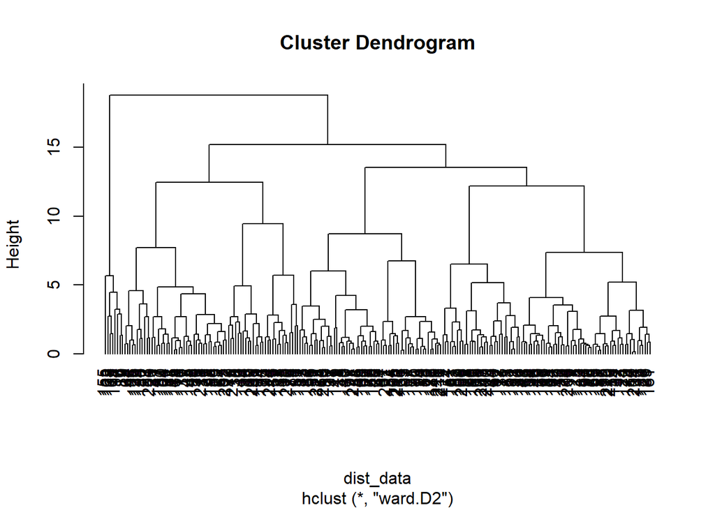

```r
# 集約した成分値の取得
data.pca <- data.frame(pca.res$x[,1:5])

# 負の値を正の値に
data.pca$PC1 <- data.pca$PC1 * -1
data.pca$PC3 <- data.pca$PC3 * -1

# 変数名の変更
colnames(data.pca) <- c("活動性", "運動志向性", "文化志向性", "自己研鑽志向性", "ギャンブル志向")

# 階層的クラスタリング
## データの標準化
data_std <- scale(data.pca)
## 距離データの取得
dist_data <- dist(data_std)
## 階層的クラスタリング
hc.res <- hclust(dist_data, method = "ward.D2")
## デンドログラムの描画
plot(hc.res, hang = -1)
```

このデンドログラムの結果から6つのクラスタに分けることが妥当だろうと考え，6つに分けることにしました．

```r
# クラスタリング
cluster <- cutree(hc.res, k = 6)
data.pca$cluster <- cluster
```

それぞれのクラスタに属するデータの特徴を調べるためにグラフ化することにしました．

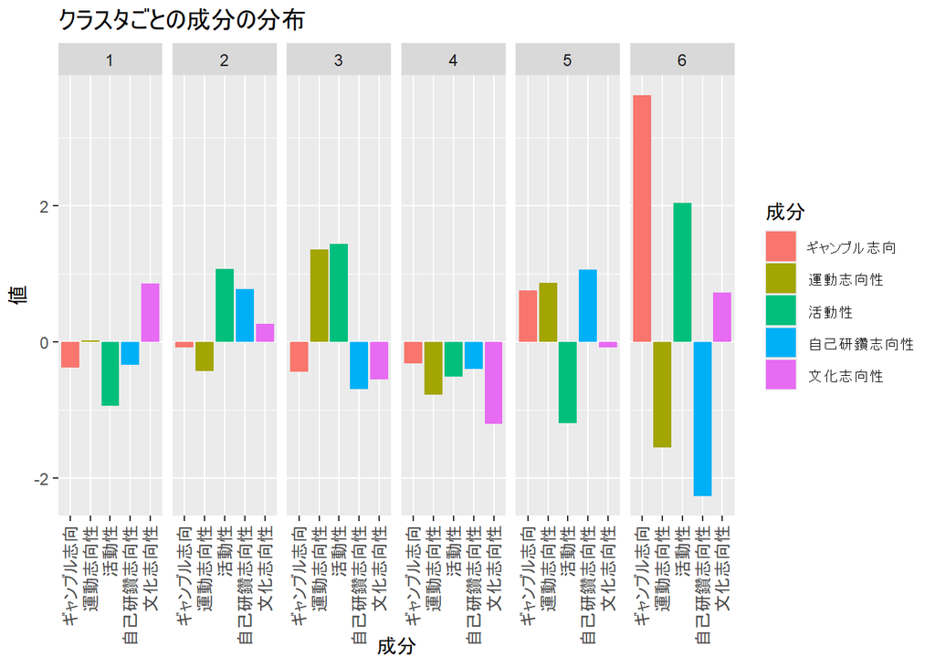

```r
library(tidyverse)
data.pca.long <- pivot_longer(data.pca,
                              cols = c(活動性, 運動志向性, 文化志向性, 自己研鑽志向性, ギャンブル志向),
                              names_to = "成分",
                              values_to = "値")

ggplot(data.pca.long, aes(x = 成分, y = 値, fill = 成分)) +
  geom_bar( stat="summary", fun.data = mean_se) +
  labs(title = "クラスタごとの成分の分布", x = "成分", y = "値") +
  theme(axis.text.x = element_text(angle = 90, hjust = 1, vjust = 0.5))+
  facet_wrap(~cluster, nrow = 1)
```

```r
data$満足度<- (data$Q23+data$Q24+8-data$Q25)/3

# クラスタごとの満足度の平均値
data$cluster <- as.factor(cluster)
aggregate(満足度 ~ cluster,data, FUN = mean)
```

```
##   cluster   満足度
## 1       1 4.327586
## 2       2 4.748428
## 3       3 4.471264
## 4       4 4.531746
## 5       5 3.927083
## 6       6 4.458333
```

```r
#分散分析
anova_res <- aov(満足度 ~ cluster, data = data)
summary(anova_res)
```

```
##              Df Sum Sq Mean Sq F value Pr(>F)
## cluster       5   14.6   2.913   1.821   0.11
## Residuals   216  345.5   1.599
```

この結果から，各クラスタでの余暇の過ごし方への満足度に有意な差はないことがわかりました．